# From Data to Insight : Uncovering Hidden Wellness Patterns in the Workplace

[figure not shown]

📁 Dataset Overview The dataset used in this project provides a rich and multifaceted view of employee wellness, covering the following key dimensions:

👥 Employee Profile: Contains essential information such as employee names, job titles, start and exit dates, and reporting supervisors.

📊 Performance & Survey Metrics: Includes employee engagement scores, satisfaction ratings, and work-life balance evaluations, offering a holistic view of their workplace experience.

🎓 Training & Development: Details on various training programs, including program names, training types, outcomes, duration, cost, and trainer information.

🌍 Diversity Attributes: Covers demographic details such as gender, race/ethnicity, and marital status to support inclusive workplace analysis.

📌 Employment Status & Classification: Indicates whether employees are active or terminated, their employment type, and specific reasons for termination.

```python
# libraries
import pandas as pd
import numpy as np

from datetime import datetime

from sklearn.preprocessing import LabelEncoder, StandardScaler
from sklearn.decomposition import PCA
from sklearn.cluster import KMeans
from sklearn.metrics import silhouette_score
from sklearn.cluster import AgglomerativeClustering
from sklearn.mixture import GaussianMixture

import matplotlib.pyplot as plt
import seaborn as sns
from matplotlib.colors import ListedColormap
from matplotlib.lines import Line2D
from mpl_toolkits.mplot3d import Axes3D
from matplotlib.colors import ListedColormap

import warnings
warnings.filterwarnings('ignore')
```

```python
# Get the Data
df = pd.read_csv("Messy_HR_Dataset_Detailed.csv")

df.head()
```

|  | Unnamed: 0 | FirstName | LastName | StartDate | ExitDate | Title | Supervisor | ADEmail | BusinessUnit | EmployeeStatus | ... | Satisfaction Score | Work-Life Balance Score | Training Date | Training Program Name | Training Type | Training Outcome | Location | Trainer | Training Duration(Days) | Training Cost |
| --- | --- | --- | --- | --- | --- | --- | --- | --- | --- | --- | --- | --- | --- | --- | --- | --- | --- | --- | --- | --- | --- |
| 0 | 0 | Uriah | Bridges | 20-Sep-19 | NaN | Production Technician I | Peter Oneill | uriah.bridges@bilearner.com | CCDR | Active | ... | 2 | 3 | 15-Jul-23 | Leadership Development | Internal | Failed | South Marisa | Taylor Rodriguez | 2 | 606.11 |
| 1 | 1 | Paula | Small | 11-Feb-23 | NaN | Production Technician I | Renee Mccormick | paula.small@bilearner.com | EW | Active | ... | 1 | 5 | 12-Sep-22 | Customer Service | External | Incomplete | Tammieville | Kelly Patterson DDS | 4 | 673.02 |
| 2 | 2 | Edward | Buck | 10-Dec-18 | NaN | Area Sales Manager | Crystal Walker | edward.buck@bilearner.com | PL | Active | ... | 2 | 1 | 13-Aug-22 | Leadership Development | External | Failed | East Roberthaven | Taylor Thomas | 2 | 413.28 |
| 3 | 3 | Michael | Riordan | 21-Jun-21 | NaN | Area Sales Manager | Rebekah Wright | michael.riordan@bilearner.com | CCDR | Active | ... | 5 | 4 | 15-Dec-22 | Project Management | External | Completed | Garzatown | Holly Elliott | 3 | 663.78 |
| 4 | 4 | Jasmine | Onque | 29-Jun-19 | NaN | Area Sales Manager | Jason Kim | jasmine.onque@bilearner.com | TNS | Active | ... | 5 | 3 | 13-Jul-23 | Technical Skills | External | Failed | Lake Meganville | Donald Martinez | 5 | 399.03 |

5 rows × 39 columns

# Data Exploration

```python
print(f"We have {df.shape[0]} rows and {df.shape[1]} columns")
```

```
We have 3150 rows and 39 columns
```

```python
df.info()
```

```
<class 'pandas.core.frame.DataFrame'>
RangeIndex: 3150 entries, 0 to 3149
Data columns (total 39 columns):
 #   Column                      Non-Null Count  Dtype
---  ------                      --------------  -----
 0   Unnamed: 0                  3150 non-null   int64
 1   FirstName                   3150 non-null   object
 2   LastName                    3150 non-null   object
 3   StartDate                   3150 non-null   object
 4   ExitDate                    1606 non-null   object
 5   Title                       3150 non-null   object
 6   Supervisor                  3150 non-null   object
 7   ADEmail                     3150 non-null   object
 8   BusinessUnit                3150 non-null   object
 9   EmployeeStatus              3150 non-null   object
```

[output cut: 31 more lines]

```python
print(df.isnull().sum())
```

```
Unnamed: 0                       0
FirstName                        0
LastName                         0
StartDate                        0
ExitDate                      1544
Title                            0
Supervisor                       0
ADEmail                          0
BusinessUnit                     0
EmployeeStatus                   0
EmployeeType                     0
PayZone                          0
EmployeeClassificationType       0
TerminationType                  0
TerminationDescription        1544
DepartmentType                   0
Division                         0
DOB                              0
State                            0
JobFunctionDescription           0
GenderCode                       0
LocationCode                     0
RaceDesc                         0
MaritalDesc                      0
Performance Score                0
Current Employee Rating          0
Employee ID                      0
Survey Date                      0
Engagement Score                 0
Satisfaction Score               0
Work-Life Balance Score          0
Training Date                    0
Training Program Name            0
Training Type                    0
Training Outcome                 0
Location                         0
Trainer                          0
Training Duration(Days)          0
Training Cost                    0
dtype: int64
```

We have some features with null values

```python
df.describe()
```

|  | Unnamed: 0 | LocationCode | Current Employee Rating | Employee ID | Engagement Score | Satisfaction Score | Work-Life Balance Score | Training Duration(Days) | Training Cost |
| --- | --- | --- | --- | --- | --- | --- | --- | --- | --- |
| count | 3150.000000 | 3150.000000 | 3150.000000 | 3150.000000 | 3150.000000 | 3150.000000 | 3150.000000 | 3150.000000 | 3150.000000 |
| mean | 1495.748254 | 45155.332698 | 2.968254 | 2502.748254 | 2.943492 | 3.021270 | 2.992381 | 2.971746 | 560.525889 |
| std | 867.007861 | 30019.418852 | 1.020717 | 866.241991 | 1.430727 | 1.407413 | 1.409244 | 1.415390 | 262.485994 |
| min | 0.000000 | 1013.000000 | 1.000000 | 1001.000000 | 1.000000 | 1.000000 | 1.000000 | 1.000000 | 100.040000 |
| 25% | 746.000000 | 17616.500000 | 2.000000 | 1750.250000 | 2.000000 | 2.000000 | 2.000000 | 2.000000 | 331.475000 |
| 50% | 1495.500000 | 44455.500000 | 3.000000 | 2504.500000 | 3.000000 | 3.000000 | 3.000000 | 3.000000 | 574.300000 |
| 75% | 2246.750000 | 71713.250000 | 3.000000 | 3254.750000 | 4.000000 | 4.000000 | 4.000000 | 4.000000 | 788.070000 |
| max | 2999.000000 | 98052.000000 | 5.000000 | 4000.000000 | 5.000000 | 5.000000 | 5.000000 | 5.000000 | 999.970000 |

```python
df.columns
```

```
Index(['Unnamed: 0', 'FirstName', 'LastName', 'StartDate', 'ExitDate', 'Title',
       'Supervisor', 'ADEmail', 'BusinessUnit', 'EmployeeStatus',
       'EmployeeType', 'PayZone', 'EmployeeClassificationType',
       'TerminationType', 'TerminationDescription', 'DepartmentType',
       'Division', 'DOB', 'State', 'JobFunctionDescription', 'GenderCode',
       'LocationCode', 'RaceDesc', 'MaritalDesc', 'Performance Score',
       'Current Employee Rating', 'Employee ID', 'Survey Date',
       'Engagement Score', 'Satisfaction Score', 'Work-Life Balance Score',
       'Training Date', 'Training Program Name', 'Training Type',
       'Training Outcome', 'Location', 'Trainer', 'Training Duration(Days)',
       'Training Cost'],
      dtype='object')
```

```python
print(f'We have {df.shape[0]} Rows and {df.shape[1]} Columns in our dataset')
```

```
We have 3150 Rows and 39 Columns in our dataset
```

lets analyze dataset feature by feature

Unnamed 0 is a index feature so we dont need it in our analsis

```python
df['Employee ID'].unique()
```

```
array([3427, 3428, 3429, ..., 3424, 3425, 3426], shape=(3000,))
```

```python
duplicate = df[df['Employee ID'].duplicated()]
```

```python
duplicate
```

|  | Unnamed: 0 | FirstName | LastName | StartDate | ExitDate | Title | Supervisor | ADEmail | BusinessUnit | EmployeeStatus | ... | Satisfaction Score | Work-Life Balance Score | Training Date | Training Program Name | Training Type | Training Outcome | Location | Trainer | Training Duration(Days) | Training Cost |
| --- | --- | --- | --- | --- | --- | --- | --- | --- | --- | --- | --- | --- | --- | --- | --- | --- | --- | --- | --- | --- | --- |
| 3000 | 1801 | Kayley | Romero | 12-Aug-18 | 13-Jun-22 | IT Support | Michael Webb | kayley.romero@bilearner.com | MSC | Active | ... | 2 | 2 | 21-Feb-23 | Technical Skills | External | Passed | Pamelaport | Joseph Mays | 3 | 713.03 |
| 3001 | 1190 | Terrell | Crosby | 18-Feb-22 | NaN | Production Technician I | Christina Powell | terrell.crosby@bilearner.com | BPC | Active | ... | 1 | 2 | 06-Feb-23 | Leadership Development | Internal | Completed | New Hannah | George Stevenson | 3 | 586.50 |
| 3002 | 1817 | Monica | Pham | 04-Aug-22 | NaN | IT Manager - Support | Jesse Archer | monica.pham@bilearner.com | PYZ | Active | ... | 2 | 1 | 14-Dec-22 | Leadership Development | Internal | Passed | Nelsonstad | Carrie Thompson | 2 | 804.01 |
| 3003 | 251 | Ramon | Fleming | 22-Jul-21 | NaN | Production Technician I | Chad Ramirez | ramon.fleming@bilearner.com | SVG | Active | ... | 4 | 4 | 06-Sep-22 | Customer Service | Internal | Incomplete | Jillside | David Underwood | 2 | 288.16 |
| 3004 | 2505 | Braeden | Moss | 19-Aug-21 | 25-May-23 | Production Technician I | Lynn Beasley DVM | braeden.moss@bilearner.com | TNS | Terminated for Cause | ... | 4 | 3 | 17-May-23 | Communication Skills | External | Completed | Simpsonland | Alex Scott | 2 | 275.36 |
| ... | ... | ... | ... | ... | ... | ... | ... | ... | ... | ... | ... | ... | ... | ... | ... | ... | ... | ... | ... | ... | ... |
| 3145 | 450 | Oscar | Lopez | 22-Oct-18 | 07-Apr-20 | Network Engineer | Christian Ortega | oscar.lopez@bilearner.com | MSC | Active | ... | 3 | 4 | 04-Jun-23 | Communication Skills | External | Passed | Markhaven | Jeremy Townsend | 1 | 888.55 |
| 3146 | 2164 | Cruz | Arellano | 17-Sep-19 | NaN | Area Sales Manager | Patricia Martinez | cruz.arellano@bilearner.com | SVG | Active | ... | 5 | 5 | 06-Oct-22 | Customer Service | Internal | Completed | North Michaelbury | Jacob Johnson | 2 | 745.31 |
| 3147 | 2372 | Makenna | Foster | 20-Apr-21 | 17-Sep-22 | Production Technician I | Timothy Pratt | makenna.foster@bilearner.com | CCDR | Active | ... | 1 | 1 | 28-Jul-23 | Communication Skills | Internal | Incomplete | Stephaniemouth | Debbie Arnold | 1 | 543.46 |
| 3148 | 2012 | Cordell | Vazquez | 21-Aug-21 | NaN | Production Manager | Paula Henderson | cordell.vazquez@bilearner.com | BPC | Active | ... | 3 | 5 | 29-Oct-22 | Project Management | External | Failed | Port Joshuaborough | Shelby Fields | 4 | 816.24 |
| 3149 | 270 | Sonia | Skinner | 28-Jun-20 | NaN | Production Technician II | Connor Galloway | sonia.skinner@bilearner.com | PYZ | Active | ... | 4 | 1 | 24-Apr-23 | Technical Skills | Internal | Failed | East Vincent | Jennifer Lopez | 2 | 982.33 |

150 rows × 39 columns

We have 150 rows of duplicate data

```python
df.drop_duplicates(subset=['Employee ID'],keep='first', inplace = True)
```

```python
df.shape
```

```
(3000, 39)
```

```python
df.columns
```

```
Index(['Unnamed: 0', 'FirstName', 'LastName', 'StartDate', 'ExitDate', 'Title',
       'Supervisor', 'ADEmail', 'BusinessUnit', 'EmployeeStatus',
       'EmployeeType', 'PayZone', 'EmployeeClassificationType',
       'TerminationType', 'TerminationDescription', 'DepartmentType',
       'Division', 'DOB', 'State', 'JobFunctionDescription', 'GenderCode',
       'LocationCode', 'RaceDesc', 'MaritalDesc', 'Performance Score',
       'Current Employee Rating', 'Employee ID', 'Survey Date',
       'Engagement Score', 'Satisfaction Score', 'Work-Life Balance Score',
       'Training Date', 'Training Program Name', 'Training Type',
       'Training Outcome', 'Location', 'Trainer', 'Training Duration(Days)',
       'Training Cost'],
      dtype='object')
```

```python
print(df[['PayZone','DepartmentType','JobFunctionDescription','Division',]].head(15))
```

```
   PayZone     DepartmentType JobFunctionDescription              Division
0   Zone C  Production                    Accounting  Finance & Accounting
1   Zone A  Production                         Labor                Aerial
2   Zone B              Sales              Assistant         General - Sga
3   Zone A              Sales                  Clerk  Finance & Accounting
4   Zone A              Sales                Laborer         General - Con
5   Zone B              Sales                 Driver      Field Operations
6   Zone B              Sales             Technician         General - Eng
7   Zone C              Sales               Engineer             Engineers
8   Zone B              Sales    Executive Assistant             Executive
9   Zone B              Sales               Engineer             Engineers
10  Zone B              Sales             Technician      Field Operations
11  Zone C              Sales             Technician         General - Con
12  Zone A              Sales                Splicer              Splicing
13  Zone A              Sales             Controller  Finance & Accounting
14  Zone A              Sales                Lineman         General - Con
```

# Uneccesary features of data

Unnamed: 0', 'FirstName', 'LastName', 'ADEmail', 'State', 'RaceDesc','DepartmentType','Division', 'Survey Date','Training Date','Location', 'Trainer', 'Training Duration(Days)', 'Training Cost','TerminationType', 'TerminationDescription','Training Program Name', 'Training Type','EmployeeClassificationType','MaritalDesc','Supervisor'

```python
df.head()
```

|  | Unnamed: 0 | FirstName | LastName | StartDate | ExitDate | Title | Supervisor | ADEmail | BusinessUnit | EmployeeStatus | ... | Satisfaction Score | Work-Life Balance Score | Training Date | Training Program Name | Training Type | Training Outcome | Location | Trainer | Training Duration(Days) | Training Cost |
| --- | --- | --- | --- | --- | --- | --- | --- | --- | --- | --- | --- | --- | --- | --- | --- | --- | --- | --- | --- | --- | --- |
| 0 | 0 | Uriah | Bridges | 20-Sep-19 | NaN | Production Technician I | Peter Oneill | uriah.bridges@bilearner.com | CCDR | Active | ... | 2 | 3 | 15-Jul-23 | Leadership Development | Internal | Failed | South Marisa | Taylor Rodriguez | 2 | 606.11 |
| 1 | 1 | Paula | Small | 11-Feb-23 | NaN | Production Technician I | Renee Mccormick | paula.small@bilearner.com | EW | Active | ... | 1 | 5 | 12-Sep-22 | Customer Service | External | Incomplete | Tammieville | Kelly Patterson DDS | 4 | 673.02 |
| 2 | 2 | Edward | Buck | 10-Dec-18 | NaN | Area Sales Manager | Crystal Walker | edward.buck@bilearner.com | PL | Active | ... | 2 | 1 | 13-Aug-22 | Leadership Development | External | Failed | East Roberthaven | Taylor Thomas | 2 | 413.28 |
| 3 | 3 | Michael | Riordan | 21-Jun-21 | NaN | Area Sales Manager | Rebekah Wright | michael.riordan@bilearner.com | CCDR | Active | ... | 5 | 4 | 15-Dec-22 | Project Management | External | Completed | Garzatown | Holly Elliott | 3 | 663.78 |
| 4 | 4 | Jasmine | Onque | 29-Jun-19 | NaN | Area Sales Manager | Jason Kim | jasmine.onque@bilearner.com | TNS | Active | ... | 5 | 3 | 13-Jul-23 | Technical Skills | External | Failed | Lake Meganville | Donald Martinez | 5 | 399.03 |

5 rows × 39 columns

```python
df['EmployeeStatus'].unique()
```

```
array(['Active', 'Future Start', 'Voluntarily Terminated',
       'Leave of Absence', 'Terminated for Cause'], dtype=object)
```

```python
# Encode EmployeeStatus
status_mapping = {
    'Active': 0,
    'Future Start': 1,
    'Leave of Absence': 2,
    'Voluntarily Terminated': 3,
    'Terminated for Cause': 4
}
df['EmployeeStatus_Encoded'] = df['EmployeeStatus'].map(status_mapping)
```

```python
df['Training Outcome'].unique()
```

```
array(['Failed', 'Incomplete', 'Completed', 'Passed'], dtype=object)
```

```python
# lets encode the training outcome
outcome_mapping = {
    'Incomplete':0,
    'Failed': 1,
    'Completed': 2,
    'Passed': 3
}
df['TrainingOutcome_Encoded'] = df['Training Outcome'].map(outcome_mapping)
```

```python
# lets check the newly made columns
df.columns
```

```
Index(['Unnamed: 0', 'FirstName', 'LastName', 'StartDate', 'ExitDate', 'Title',
       'Supervisor', 'ADEmail', 'BusinessUnit', 'EmployeeStatus',
       'EmployeeType', 'PayZone', 'EmployeeClassificationType',
       'TerminationType', 'TerminationDescription', 'DepartmentType',
       'Division', 'DOB', 'State', 'JobFunctionDescription', 'GenderCode',
       'LocationCode', 'RaceDesc', 'MaritalDesc', 'Performance Score',
       'Current Employee Rating', 'Employee ID', 'Survey Date',
       'Engagement Score', 'Satisfaction Score', 'Work-Life Balance Score',
       'Training Date', 'Training Program Name', 'Training Type',
       'Training Outcome', 'Location', 'Trainer', 'Training Duration(Days)',
       'Training Cost', 'EmployeeStatus_Encoded', 'TrainingOutcome_Encoded'],
      dtype='object')
```

```python
df['PayZone'].unique()
```

```
array(['Zone C', 'Zone A', 'Zone B'], dtype=object)
```

```python
# map the payzone
payzone_mapping = {
    'Zone A': 0,
    'Zone B': 1,
    'Zone C': 2
}
df['PayZone_Encoded'] = df['PayZone'].map(payzone_mapping)
```

```python
df['Performance Score'].unique()
```

```
array(['Fully Meets', 'Exceeds', 'Needs Improvement', 'PIP'], dtype=object)
```

This feature indicates performance appraisal levels:

'Fully Meets' – Meets expectations.

'Exceeds' – Exceeds expectations.

'Needs Improvement' – Below expectations.

'PIP' – On Performance Improvement Plan (lowest tier).

```python
performance_mapping = {
    'PIP': 0,
    'Needs Improvement': 1,
    'Fully Meets': 2,
    'Exceeds': 3
}
df['PerformanceScore_Encoded'] = df['Performance Score'].map(performance_mapping)
```

```python
df['JobFunctionDescription'].unique()
```

```
array(['Accounting', 'Labor', 'Assistant', 'Clerk', 'Laborer', 'Driver',
       'Technician', 'Engineer', 'Executive Assistant', 'Splicer',
       'Controller', 'Lineman', 'Coordinator', 'Director', 'Supervisor',
       'Driller', 'Specialist', 'Operator', 'Foreman', 'Manager',
       'Tower Hand', 'Mechanic', 'Flagger', 'Groundman',
       'Model Assistant', 'Administrator', 'Project Manager',
       'Electrician', 'Project Controls', 'Top Hand', 'Administrative',
       'Locator', 'Billing', 'Cpo', 'Drafter', 'Vp',
       'Construction Manager', 'Welder', 'Field Project Manager',
       'Apprentice', 'Runner', 'Inspector', 'Field Technician',
       'Associate', 'Administration', 'Intern', 'Planner', 'Accountant',
       'General Manager', 'Clerical', 'Principal', 'Tester', 'Purchasing',
       'Helper', 'Safety', 'Crew Leader', 'Program Manager', 'Shop',
       'Project Coordinator', 'Estimator', 'Recruiting', 'Support', 'Ceo',
       'Safety Manager', 'Warehouse Technician', 'Analyst', 'Generalist',
       'Business Development', 'Cio', 'Executive', 'Cfo', 'Contracts',
       'Chief Operating Officer', 'Helpdesk', 'Evp', 'Civil Hand',
       'Services', 'Recruiter', 'Traffic', 'Attendant', 'Svp',
       'Warehouse', 'Warehouse Manager'], dtype=object)
```

Here is too many value in job description function feature so we aggrgate this value into small table

```python
def map_job_function(x):
    x = str(x).lower()
    if any(k in x for k in ['ceo', 'cfo', 'coo', 'cio', 'evp', 'svp', 'vp', 'executive', 'principal', 'chief operating officer']):
        return 'Executive'
    elif any(k in x for k in ['manager', 'project manager', 'field project manager', 'construction manager', 'general manager', 'supervisor', 'director', 'program manager', 'crew leader', 'safety manager', 'project controls', 'project coordinator']):
        return 'Management'
    elif any(k in x for k in ['technician', 'field technician', 'welder', 'electrician', 'mechanic', 'splicer', 'lineman', 'tower hand', 'driller', 'operator', 'tester', 'apprentice', 'inspector', 'locator', 'drafter', 'warehouse technician']):
        return 'Technician'
    elif any(k in x for k in ['assistant', 'executive assistant', 'administrative', 'administration', 'clerk', 'clerical', 'coordinator', 'administrator', 'helpdesk', 'runner', 'intern', 'attendant', 'model assistant']):
        return 'Administrative'
    elif any(k in x for k in ['engineer', 'specialist', 'analyst', 'planner', 'estimator', 'accountant', 'accounting', 'billing', 'purchasing', 'contracts', 'business development', 'recruiting', 'recruiter', 'support', 'safety', 'traffic', 'services', 'generalist']):
        return 'Specialist'
    elif any(k in x for k in ['labor', 'laborer', 'driver', 'flagger', 'groundman', 'civil hand', 'helper']):
        return 'Labor'
    else:
        return 'Other'

df['JobFunctionGroup'] = df['JobFunctionDescription'].apply(map_job_function)

df.drop(columns=['JobFunctionDescription'], inplace=True)

print(df['JobFunctionGroup'].value_counts())
```

```
JobFunctionGroup
Technician        842
Labor             653
Management        424
Specialist        383
Other             306
Administrative    233
Executive         159
Name: count, dtype: int64
```

```python
# Define mapping
job_group_encoding = {
    'Technician': 0,
    'Labor': 1,
    'Management': 2,
    'Specialist': 3,
    'Other': 4,
    'Administrative': 5,
    'Executive': 6
}

df['JobFunctionGroup_Encoded'] = df['JobFunctionGroup'].map(job_group_encoding)

df.drop(columns=['JobFunctionGroup'], inplace=True)

print(df['JobFunctionGroup_Encoded'].value_counts().sort_index())
```

```
JobFunctionGroup_Encoded
0    842
1    653
2    424
3    383
4    306
5    233
6    159
Name: count, dtype: int64
```

```python
df['EmployeeType'].unique()
```

```
array(['Contract', 'Full-Time', 'Part-Time'], dtype=object)
```

```python
# Define mapping
employee_type_mapping = {
    'Contract': 0,
    'Part-Time': 1,
    'Full-Time': 2
}

# Apply encoding
df['EmployeeType_Encoded'] = df['EmployeeType'].map(employee_type_mapping)

# Drop original column to avoid redundancy
df.drop(columns=['EmployeeType'], inplace=True)

print(df['EmployeeType_Encoded'].value_counts().sort_index())
```

```
EmployeeType_Encoded
0    1008
1     954
2    1038
Name: count, dtype: int64
```

```python
df['DOB']
```

```
0       07-10-1969
1       30-08-1965
2       06-10-1991
3       04-04-1998
4       29-08-1969
           ...
2995    23-06-1998
2996    10-06-2001
2997    27-01-1997
2998    28-05-1954
2999    11-09-1990
Name: DOB, Length: 3000, dtype: object
```

# DATA CLEANING

```python
# create a copy of data
cleaned_df = df.copy()
```

```python
cleaned_df.columns
```

```
Index(['Unnamed: 0', 'FirstName', 'LastName', 'StartDate', 'ExitDate', 'Title',
       'Supervisor', 'ADEmail', 'BusinessUnit', 'EmployeeStatus', 'PayZone',
       'EmployeeClassificationType', 'TerminationType',
       'TerminationDescription', 'DepartmentType', 'Division', 'DOB', 'State',
       'GenderCode', 'LocationCode', 'RaceDesc', 'MaritalDesc',
       'Performance Score', 'Current Employee Rating', 'Employee ID',
       'Survey Date', 'Engagement Score', 'Satisfaction Score',
       'Work-Life Balance Score', 'Training Date', 'Training Program Name',
       'Training Type', 'Training Outcome', 'Location', 'Trainer',
       'Training Duration(Days)', 'Training Cost', 'EmployeeStatus_Encoded',
       'TrainingOutcome_Encoded', 'PayZone_Encoded',
       'PerformanceScore_Encoded', 'JobFunctionGroup_Encoded',
       'EmployeeType_Encoded'],
      dtype='object')
```

```python
# Drop Uneccesary features of data
cleaned_df.drop(['Unnamed: 0', 'FirstName', 'LastName', 'ADEmail',
       'State', 'LocationCode', 'RaceDesc',
       'Survey Date','Training Date','Location', 'Trainer', 'Training Duration(Days)',
       'Training Cost','TerminationType', 'TerminationDescription', 'Training Type','EmployeeClassificationType'
       , 'Title', 'Supervisor', 'BusinessUnit', 'Division', 'Training Program Name', 'Training Outcome', 'MaritalDesc',
       'GenderCode','EmployeeStatus', 'PayZone', 'DepartmentType','Performance Score', 'Employee ID',],axis=1,inplace=True)
```

# Uneccesary features of data

Unnamed: 0', 'FirstName', 'LastName', 'ADEmail', 'State', 'RaceDesc','DepartmentType','Division', 'Survey Date','Training Date','Location', 'Trainer', 'Training Duration(Days)', 'Training Cost','TerminationType', 'TerminationDescription','Training Program Name', 'Training Type','EmployeeClassificationType','MaritalDesc','Supervisor'

```python
cleaned_df.head()
```

|  | StartDate | ExitDate | DOB | Current Employee Rating | Engagement Score | Satisfaction Score | Work-Life Balance Score | EmployeeStatus_Encoded | TrainingOutcome_Encoded | PayZone_Encoded | PerformanceScore_Encoded | JobFunctionGroup_Encoded | EmployeeType_Encoded |
| --- | --- | --- | --- | --- | --- | --- | --- | --- | --- | --- | --- | --- | --- |
| 0 | 20-Sep-19 | NaN | 07-10-1969 | 4 | 1 | 2 | 3 | 0 | 1 | 2 | 2 | 3 | 0 |
| 1 | 11-Feb-23 | NaN | 30-08-1965 | 3 | 2 | 1 | 5 | 0 | 0 | 0 | 2 | 1 | 0 |
| 2 | 10-Dec-18 | NaN | 06-10-1991 | 4 | 1 | 2 | 1 | 0 | 1 | 1 | 2 | 5 | 2 |
| 3 | 21-Jun-21 | NaN | 04-04-1998 | 2 | 5 | 5 | 4 | 0 | 2 | 0 | 2 | 5 | 0 |
| 4 | 29-Jun-19 | NaN | 29-08-1969 | 3 | 2 | 5 | 3 | 0 | 1 | 0 | 2 | 1 | 0 |

```python
cleaned_df.info()
```

```
<class 'pandas.core.frame.DataFrame'>
Index: 3000 entries, 0 to 2999
Data columns (total 13 columns):
 #   Column                    Non-Null Count  Dtype
---  ------                    --------------  -----
 0   StartDate                 3000 non-null   object
 1   ExitDate                  1533 non-null   object
 2   DOB                       3000 non-null   object
 3   Current Employee Rating   3000 non-null   int64
 4   Engagement Score          3000 non-null   int64
 5   Satisfaction Score        3000 non-null   int64
 6   Work-Life Balance Score   3000 non-null   int64
 7   EmployeeStatus_Encoded    3000 non-null   int64
 8   TrainingOutcome_Encoded   3000 non-null   int64
 9   PayZone_Encoded           3000 non-null   int64
 10  PerformanceScore_Encoded  3000 non-null   int64
 11  JobFunctionGroup_Encoded  3000 non-null   int64
 12  EmployeeType_Encoded      3000 non-null   int64
dtypes: int64(10), object(3)
memory usage: 328.1+ KB
```

```python
cleaned_df.columns
```

```
Index(['StartDate', 'ExitDate', 'DOB', 'Current Employee Rating',
       'Engagement Score', 'Satisfaction Score', 'Work-Life Balance Score',
       'EmployeeStatus_Encoded', 'TrainingOutcome_Encoded', 'PayZone_Encoded',
       'PerformanceScore_Encoded', 'JobFunctionGroup_Encoded',
       'EmployeeType_Encoded'],
      dtype='object')
```

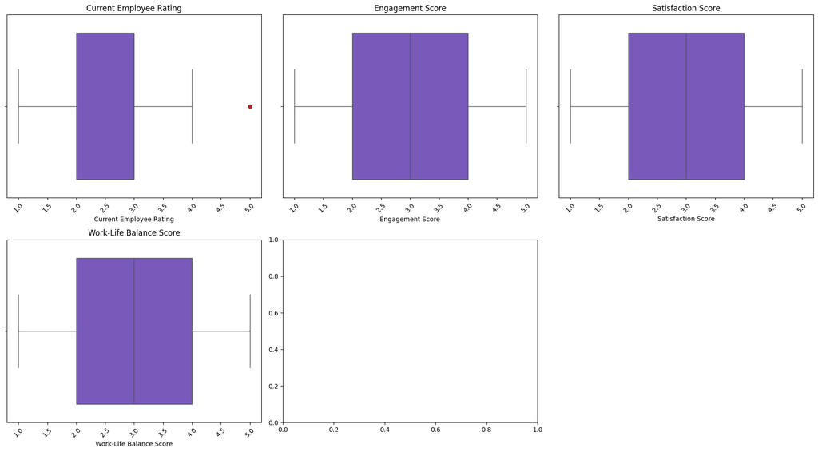

```python
# List of columns for outlier visualization
columns = [
    'Current Employee Rating',
    'Engagement Score',
    'Satisfaction Score',
    'Work-Life Balance Score'
]

fig, axes = plt.subplots(nrows=2, ncols=3, figsize=(18, 10))

axes = axes.flatten()

# Plot each boxplot in a separate subplot
for i, col in enumerate(columns):
    sns.boxplot(data=cleaned_df, x=col, ax=axes[i], color='#724ACA',
                fliersize=4,
                flierprops=dict(marker='o', markerfacecolor='red', markersize=5))
    axes[i].set_title(col, fontsize=12)
    axes[i].tick_params(axis='x', rotation=45)


axes[5].axis('off')

plt.tight_layout()
plt.show()
```